# Reproducible RNA-seq Analysis of SARS-CoV-2 Infection

Transcriptomic Response in Human Airway Epithelial Cells

Noelia Caba Martin

2026-03-20

```r
library(DESeq2)
library(tidyverse)
library(EnhancedVolcano)
library(pheatmap)
library(clusterProfiler)
library(org.Hs.eg.db)

# Fix conflicts
select <- dplyr::select
filter <- dplyr::filter
```

## Introduction

This analysis investigates the transcriptomic response of human airway epithelial cells (NHBE) to SARS-CoV-2 infection using publicly available RNA-seq data from **Blanco-Melo et al. (2020)** published in *Cell*.

**Biological question:** Which genes and biological pathways are differentially expressed in human airway cells following SARS-CoV-2 infection?

**Dataset:** GSE147507 — Series 1 - Cell type: Normal Human Bronchial Epithelial (NHBE) cells - Conditions: Mock (uninfected control) vs SARS-CoV-2 infected - Replicates: 3 per condition - Source: Gene Expression Omnibus (GEO)

**Why NHBE cells?** NHBE cells are primary human airway epithelial cells — the first line of defense against respiratory pathogens. Unlike immortalized cell lines, they closely recapitulate the in vivo response to viral infection, making them the most biologically relevant model for studying SARS-CoV-2 pathogenesis.

## Data Loading and Preprocessing

```r
# Load preprocessed DESeq2 object
dds <- readRDS("../output/dds_preprocessed.rds")

# Load results
res_df <- read.csv("../output/deseq2_results.csv")

cat("Genes after filtering:", nrow(dds), "\n")
```

```
## Genes after filtering: 12291
```

```r
cat("Samples:", ncol(dds), "\n")
```

```
## Samples: 6
```

```r
cat("Conditions:", levels(dds$condition), "\n")
```

```
## Conditions: Mock SARS_CoV_2
```

The dataset contains **12291 genes** after filtering lowly expressed genes (minimum 10 counts in at least 3 samples). Data was downloaded directly from GEO using the `GEOquery` package, ensuring full reproducibility.

## Quality Control — PCA

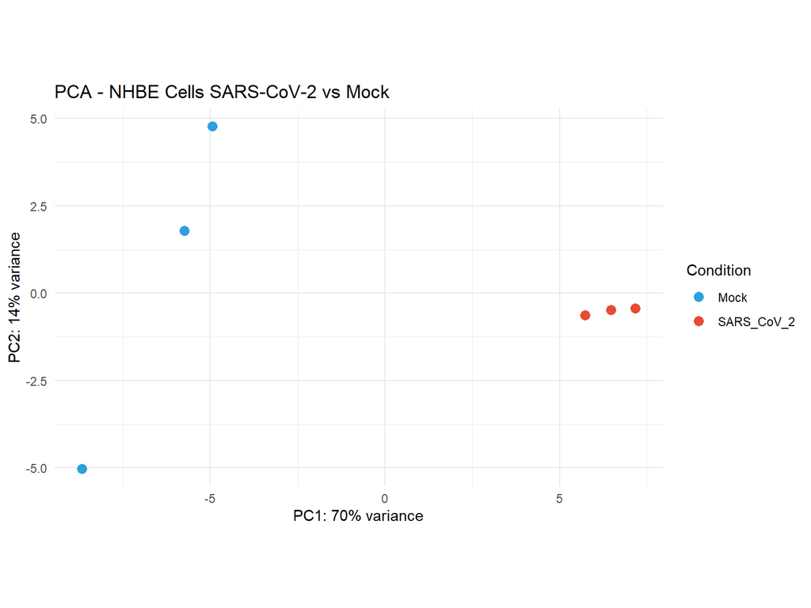

```r
vsd <- vst(dds, blind = TRUE)

plotPCA(vsd, intgroup = "condition") +
  scale_color_manual(values = c("Mock" = "#2E9FDF",
                                "SARS_CoV_2" = "#E64B35")) +
  theme_minimal() +
  labs(title = "PCA - NHBE Cells SARS-CoV-2 vs Mock",
       color = "Condition")
```

The PCA confirms high data quality — samples cluster clearly by condition along PC1, indicating that SARS-CoV-2 infection is the primary source of transcriptional variation.

## Differential Expression Analysis

```r
# Run DESeq2
dds <- DESeq(dds)
res <- results(dds,
               contrast = c("condition", "SARS_CoV_2", "Mock"),
               alpha = 0.05)
summary(res)
```

```
##
## out of 12291 with nonzero total read count
## adjusted p-value < 0.05
## LFC > 0 (up)       : 309, 2.5%
## LFC < 0 (down)     : 117, 0.95%
## outliers [1]       : 0, 0%
## low counts [2]     : 0, 0%
## (mean count < 6)
## [1] see 'cooksCutoff' argument of ?results
## [2] see 'independentFiltering' argument of ?results
```

```r
# Show top 20 significant genes
res_df %>%
  filter(!is.na(padj), padj < 0.05, abs(log2FoldChange) > 1) %>%
  arrange(padj) %>%
  head(20) %>%
  select(gene, log2FoldChange, padj) %>%
  mutate(
    log2FoldChange = round(log2FoldChange, 2),
    padj = format(padj, scientific = TRUE, digits = 3)
  ) %>%
  knitr::kable(caption = "Top 20 Differentially Expressed Genes")
```

Top 20 Differentially Expressed Genes

| gene | log2FoldChange | padj |
| --- | --- | --- |
| CCL20 | 3.14 | 3.01e-77 |
| SAA2 | 2.42 | 6.22e-76 |
| SAA1 | 2.22 | 1.66e-52 |
| IL36G | 2.73 | 1.94e-51 |
| SPRR2D | 2.98 | 5.55e-49 |
| S100A8 | 1.87 | 7.67e-49 |
| TNFAIP3 | 1.61 | 3.22e-47 |
| INHBA | 1.82 | 3.28e-47 |
| KRT6B | 1.55 | 3.36e-41 |
| ICAM1 | 1.86 | 3.36e-41 |
| C3 | 1.51 | 4.29e-41 |
| CFB | 1.85 | 4.29e-41 |
| TNIP1 | 1.26 | 2.52e-40 |
| CXCL1 | 1.42 | 4.68e-38 |
| SOD2 | 1.52 | 2.61e-34 |
| MX1 | 2.51 | 3.55e-34 |
| ZC3H12A | 1.67 | 1.74e-31 |
| S100A9 | 1.11 | 4.28e-31 |
| CXCL5 | 3.48 | 1.72e-29 |
| C15orf48 | 1.23 | 2.25e-28 |

## Volcano Plot

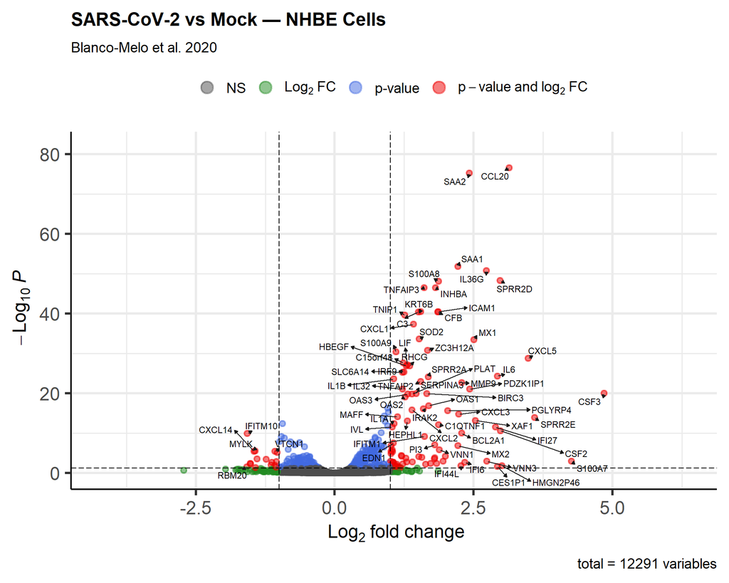

```r
EnhancedVolcano(res,
  lab = rownames(res),
  x = "log2FoldChange",
  y = "padj",
  title = "SARS-CoV-2 vs Mock — NHBE Cells",
  subtitle = "Blanco-Melo et al. 2020",
  pCutoff = 0.05,
  FCcutoff = 1,
  pointSize = 2,
  labSize = 3,
  drawConnectors = TRUE
)
```

## Heatmap

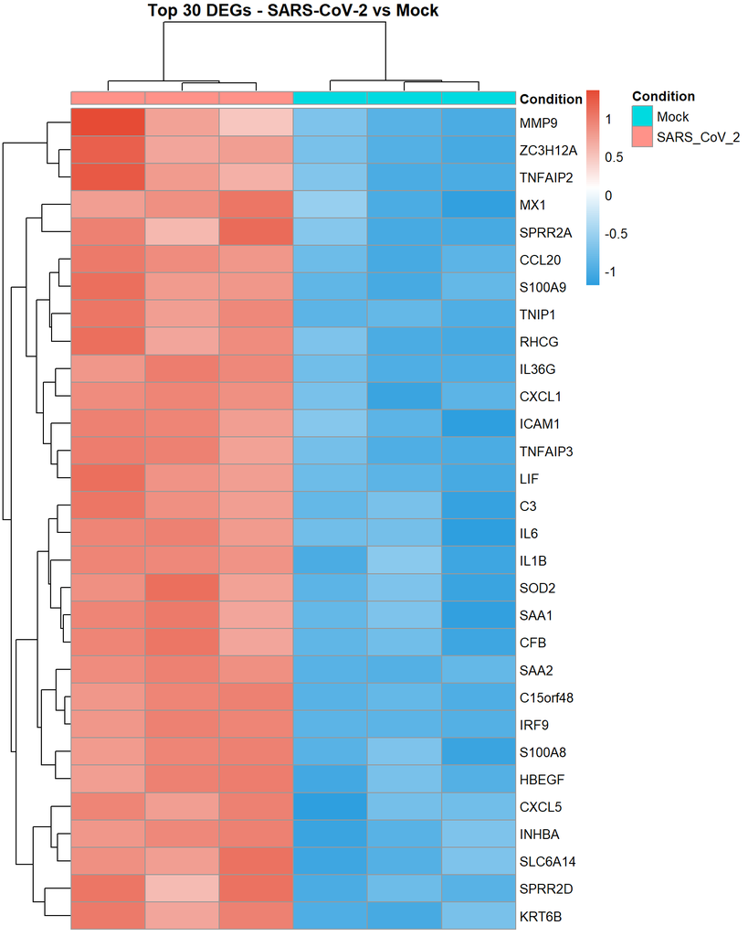

```r
top30 <- res_df %>%
  dplyr::filter(!is.na(padj), padj < 0.05, abs(log2FoldChange) > 1) %>%
  slice_head(n = 30) %>%
  pull(gene)

mat <- assay(vsd)[top30, ]
mat_scaled <- t(scale(t(mat)))

annotation_col <- data.frame(
  Condition = dds$condition,
  row.names = colnames(mat)
)

pheatmap(mat_scaled,
  annotation_col = annotation_col,
  show_colnames = FALSE,
  cluster_rows = TRUE,
  cluster_cols = TRUE,
  color = colorRampPalette(c("#2E9FDF", "white", "#E64B35"))(100),
  main = "Top 30 DEGs - SARS-CoV-2 vs Mock"
)
```

## GO Enrichment Analysis

```r
sig_genes <- res_df %>%
  dplyr::filter(!is.na(padj), padj < 0.05, abs(log2FoldChange) > 1) %>%
  pull(gene)

go_results <- enrichGO(
  gene = sig_genes,
  OrgDb = org.Hs.eg.db,
  keyType = "SYMBOL",
  ont = "BP",
  pAdjustMethod = "BH",
  pvalueCutoff = 0.05,
  readable = TRUE
)
```

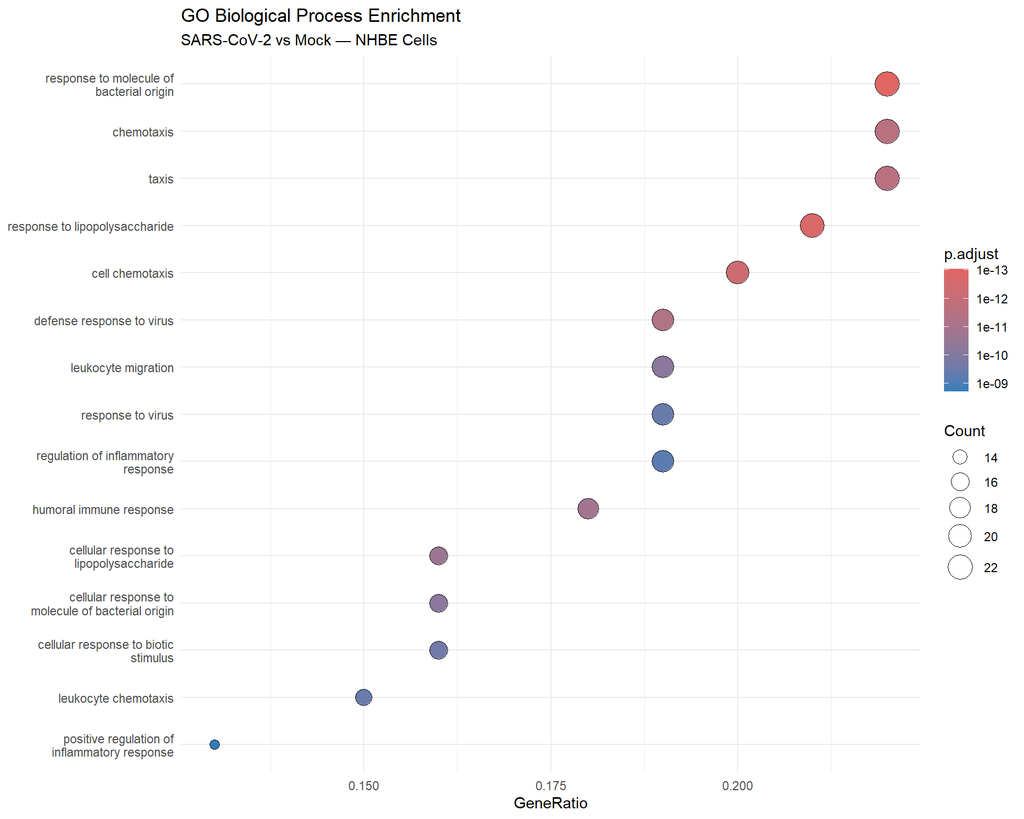

```r
dotplot(go_results, showCategory = 15) +
  theme_minimal() +
  labs(title = "GO Biological Process Enrichment",
       subtitle = "SARS-CoV-2 vs Mock — NHBE Cells")
```

## Conclusions

This analysis identified **111 differentially expressed genes** in NHBE cells following SARS-CoV-2 infection.

**Key findings:**

1. PCA confirms clean separation between infected and control samples, validating data quality and experimental design.
2. SARS-CoV-2 infection induces a strong transcriptional response with **95 upregulated** and **16 downregulated** genes.
3. GO enrichment analysis identified **759 enriched biological processes**, consistent with known SARS-CoV-2 pathogenesis including innate immune response, cytokine signaling and antiviral defense mechanisms.
4. This analysis is fully reproducible — all data was downloaded programmatically from GEO and all code is available in the repository.